# Linear regression models with linear algebra and R

Juho Kopra

2023-02-13

## 1. Scatter plot and one linear predictor

Let’s consider following data set, and draw a scatter plot out of it.

| x | y |
| --- | --- |
| 6.84 | 39 |
| 8.73 | 44 |
| 6.90 | 33 |
| 1.16 | 19 |
| 1.95 | 13 |
| 4.61 | 22 |
| 2.04 | 14 |
| 5.91 | 29 |

The scatterplot becomes

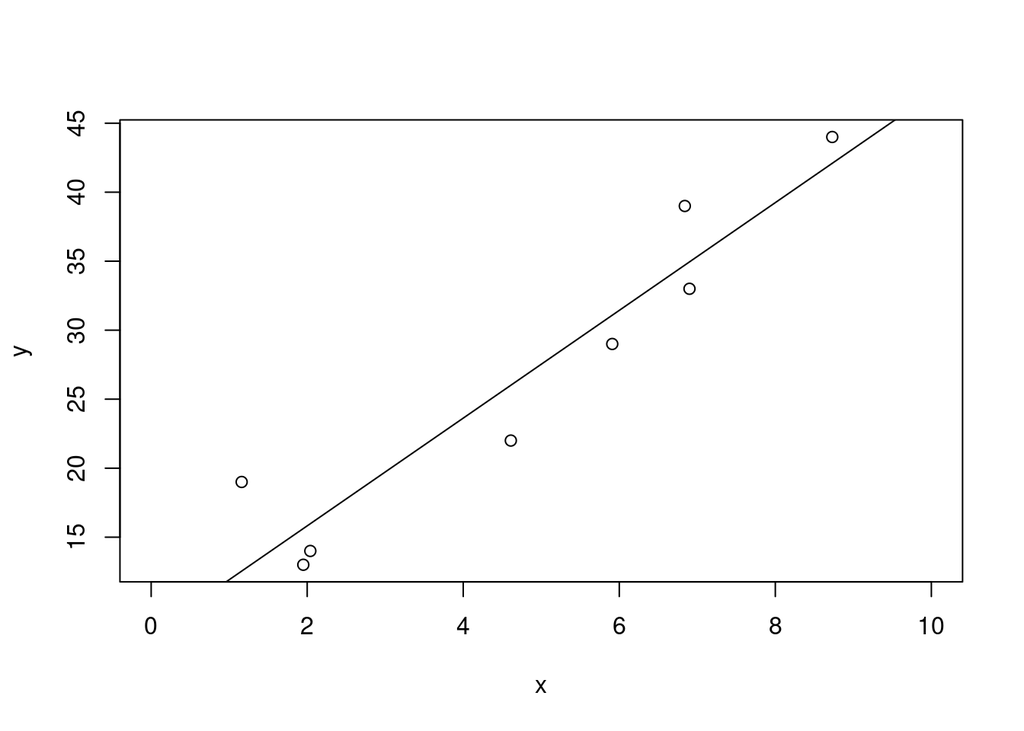

Scatterplot and a linear model with one predictor.

The coefficients of a linear regression fitted to that data set are $\beta_0=8.01$ and $\beta_1=3.90$.

### Definition

Importantly, a linear regression model with one variable is a statistical model which can be formulated as
$$\begin{equation}
Y_i = \beta_0 + \beta_1 x_i + \varepsilon_i \label{simple-regression}
\end{equation}$$
and where $i = 1,\dots,n$ and $\varepsilon_i \sim N(0,\sigma^2)$.

There the following terminology takes place

- $Y_i$ is dependent
- $\beta_0$ is an intercept
- $\beta_1$ is a slope
- $\beta_0$ and $\beta_1$ are regression coefficients or model parameters
- $x_i$ is the value of predictor aka independent aka covariate aka regressor

In equation $\eqref{simple-regression}$ we did not write estimated values of parameters down to the equation but used $\beta$-coefficients instead. When we write it down with $\beta$-coefficients we call it general form of linear model.

Linear model with multiple predictors $X_1, X_2, \ldots, X_k$ it can be written as
$$\begin{equation}
Y_i = \beta_0 + \beta_1 x_{i1} + \cdots \beta_k x_{ik}+ \varepsilon_i
\label{multiple-regression}
\end{equation}$$
and where $i = 1,\dots,n$ and $\varepsilon_i \sim N(0,\sigma^2)$.

### The fitting of linear model

We want to minimize the sum of squares of error terms $\varepsilon_i^2$, which can be written as $\varepsilon_i = Y_i - (\beta_0 + \beta_1 X_i)$. Note that error terms are in the same direction with $Y$-axis (and thus the same direction with $Y_i$).

We will not go into technical details of minimization here.

Using R we can fit the above model as follows. Assume that we have already read in data into object `dat`. We use `lm` function to fit the **l**inear **m**odel. The resulting calculation we store into object named `m1`. The data object `dat` has columns named `x` and `y` but the names could be something else as well. The first argument of `lm` is formula, which is special type in R. Formula is handy for fitting many types of models. On the left hand side of the formula one writes the dependent (e.g. what is $Y_i$), then tilde (~) and then predictor variable(s). For multiple predictors one need to put a plus sign (`+`) between the predictors.

```r
m1 <- lm(y ~ x, data=dat)
m1
```

```
##
## Call:
## lm(formula = y ~ x, data = dat)
##
## Coefficients:
## (Intercept)            x
##        8.01         3.90
```

## 2. Properties of linear models and interpretation

### Properties of linear models

To have an interpretation for $\beta_0$ and $\beta_1$ we note that:

Expected value of $Y_i$ is if we consider $x_i$ being known and fixed:
$$\begin{aligned}
E(Y_i|x_i) &= E(\beta_0 + \beta_1 x_i + \varepsilon_i) \\
&= E(\beta_0) + E(\beta_1 x_i) + E(\varepsilon_i) \\
&= E(\beta_0) + x_i E(\beta_1) + E(\varepsilon_i) \\
&= \beta_0 + \beta_1 x_i
\end{aligned}$$
because $x_i$ is constant and $E(\varepsilon_i) = 0$.

Shortly put, the above calculation gives $E(Y_i) = \beta_0 + \beta_1 x_i$, which is called a systematic part of linear model. If we replace the $\beta$-notation with their estimates, then we can use that equation to calculate fitted values: $\hat{Y_i} = \hat{\beta_0} + \hat{\beta_1}x_i$ Fitted values are calculated for the same $x_i$ values which were in the original data.

```r
fitted(m1)
```

```
##      1      2      3      4      5      6      7      8
## 34.716 42.095 34.951 12.541 15.625 26.010 15.976 31.085
```

Prediction can be obtained by the same equation but using any value. Here we predict new values using `x=10` and `x=11`.

```r
predict(m1,newdata = data.frame(x=c(10,11)))
```

```
##      1      2
## 47.053 50.958
```

### Interpretation

We want to interpret what happens in the population of our study. That is why we use equation of expected value of $Y_i$, that is $E(Y_i) = \beta_0 + \beta_1 x_i$ to give interpretation.

An interpretation of $\beta_1$ becomes available as
$$\begin{aligned}
E(Y_i|x_i) - E(Y_i|x_i+1) &= \beta_0 + \beta_1 x_i - (\beta_0
+ \beta_1 (x_i+1))\\
&= \beta_1 x_i -\beta_1 (x_i+1) \\
&= \beta_1 x_i -\beta_1 x_i+\beta_1\cdot1 \\
&= \beta_1
\end{aligned}$$

Thus, if e.g. $\beta_1 = 5.3$ then the expected value of $Y_i$ increases by $5.3$ if $x_i$ becomes increased with 1 unit.

An interpretation of intercept term $\beta_0$ becomes available if we set $x_i = 0$ since that removes $\beta_1$ from the equation. Thus $E(Y_i|x_i=0) = \beta_0 + \beta_1 \cdot 0 = \beta_0$.

## 3. Categorical predictors

The predictors may as well be categorical ones. For example, we can model the mice weights where mice have two groups in a study. We are used to do that with a t-test but here we formulate it using linear regression. The results are the very same as with t-test!

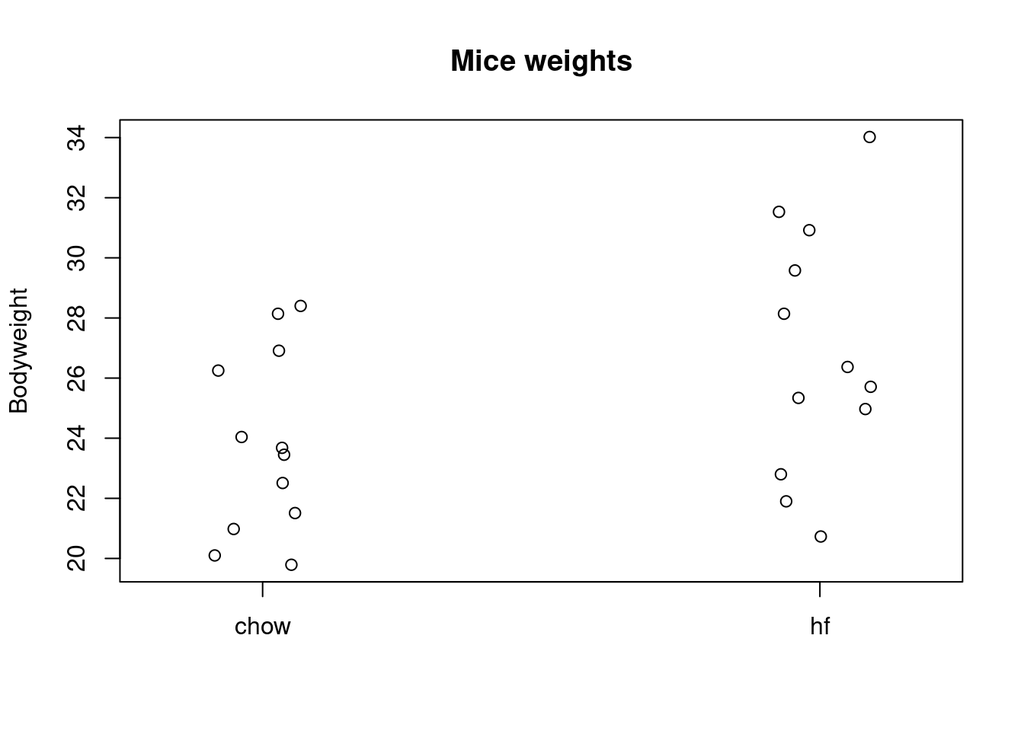

Mice weight with jitter. Example borrowed from Mike Love.

```r
m1 <- lm(Bodyweight ~ Diet, data=dat)
```

```r
summary(m1)
```

```
##
## Call:
## lm(formula = Bodyweight ~ Diet, data = dat)
##
## Residuals:
##    Min     1Q Median     3Q    Max
## -6.104 -2.436 -0.414  2.834  7.186
##
## Coefficients:
##             Estimate Std. Error t value Pr(>|t|)
## (Intercept)    23.81       1.04   22.91   <2e-16 ***
## Diethf          3.02       1.47    2.06    0.052 .
## ---
## Signif. codes:  0 '***' 0.001 '**' 0.01 '*' 0.05 '.' 0.1 ' ' 1
##
## Residual standard error: 3.6 on 22 degrees of freedom
## Multiple R-squared:  0.161,  Adjusted R-squared:  0.123
## F-statistic: 4.22 on 1 and 22 DF,  p-value: 0.0519
```

Above, the `(Intercept)` represents the average of group `chow` that is 23.81333 and the `Diethf` is parameter comparing the differences of means between the two groups. Thus, p-value $p=0.052$ tells us that these two groups do not differ from each other.

```r
t.test(Bodyweight ~ Diet, data=dat, var.equal=T)
```

```
##
##  Two Sample t-test
##
## data:  Bodyweight by Diet
## t = -2.06, df = 22, p-value = 0.052
## alternative hypothesis: true difference in means between group chow and group hf is not equal to 0
## 95 percent confidence interval:
##  -6.069152  0.027485
## sample estimates:
## mean in group chow   mean in group hf
##             23.813             26.834
```

## 4. Basics of linear algebra

Linear algebra is a branch of mathematics where instead of numbers (aka scalars) we operate on vectors and matrices. Linear algebra is a useful tool for solving systems of linear equations, and thus suitable for handling mathematics behind linear regression. Next, we go through some of the key concepts so that we can move forward to understand how linear regression can be solved.

```r
A <- matrix(c(1,2,
              3,4,
              5,6),nrow=3,ncol=2,byrow=T)
A
```

```
##      [,1] [,2]
## [1,]    1    2
## [2,]    3    4
## [3,]    5    6
```

```r
t(A)
```

```
##      [,1] [,2] [,3]
## [1,]    1    3    5
## [2,]    2    4    6
```

A matrix with only one column is called a vector.
$$d=\begin{pmatrix}
1 \\
3 \\
5
\end{pmatrix}$$

A transpose of a vector is a row vector.
$$d^T=\begin{bmatrix}
1 & 3 & 5\\
\end{bmatrix}$$

A cross product (aka matrix multiplication) of row vector with a column vector is
$$\begin{bmatrix}
1 & 2 & 3\\
\end{bmatrix}
\begin{pmatrix}
4 \\
5 \\
6
\end{pmatrix}
= \begin{bmatrix}
1\cdot 4 + 2\cdot 5 + 3\cdot 6\\
\end{bmatrix}
= \begin{bmatrix}
32\\
\end{bmatrix}$$

```r
d <- c(4,5,6)
d
```

```
## [1] 4 5 6
```

```r
t(d)
```

```
##      [,1] [,2] [,3]
## [1,]    4    5    6
```

```r
t(t(d))
```

```
##      [,1]
## [1,]    4
## [2,]    5
## [3,]    6
```

```r
c(1,2,3) %*% d
```

```
##      [,1]
## [1,]   32
```

Identity matrix is $\mathbf{I}$ has 1 on diagonal and 0 elsewhere. E.g.
$$\mathbf{I}_3=\begin{pmatrix}
1 & 0 & 0\\
0 & 1 & 0\\
0 & 0 & 1\\
\end{pmatrix}$$

```r
diag(3)
```

```
##      [,1] [,2] [,3]
## [1,]    1    0    0
## [2,]    0    1    0
## [3,]    0    0    1
```

If matrix has the same number of rows and columns, it is called a square matrix.

If a square matrix $\mathbf{B}$ has determinant, which is not zero, then $\mathbf{B}$ is invertible, which means that it is possible to calculate an inverse of matrix $\mathbf{B}$ that is $\mathbf{B^{-1}}$.

```r
# Let's create a square matrix
B <- t(A) %*% A
B
```

```
##      [,1] [,2]
## [1,]   35   44
## [2,]   44   56
```

```r
det(B) #determinant is not zero => invertible
```

```
## [1] 24
```

```r
solve(B)
```

```
##         [,1]    [,2]
## [1,]  2.3333 -1.8333
## [2,] -1.8333  1.4583
```

For invertible matrix $\mathbf{B}$ it follows that $\mathbf{B} \mathbf{B}^{-1} = \mathbf{I}$ and also $\mathbf{B}^{-1} \mathbf{B} = \mathbf{I}$.

### Solving systems of equations using linear algebra

Matrices can be used to represent a systems of equations. To understand the basic concepts, let’s have a look at following system of equations:
$$\begin{aligned}
a + b + c &= 6\\
3a - 2b + c &= 2\\
2a + b - c &= 1
\end{aligned}$$

$$\,
\begin{pmatrix}
1&1&1\\
3&-2&1\\
2&1&-1
\end{pmatrix}
\begin{pmatrix}
a\\
b\\
c
\end{pmatrix} =
\begin{pmatrix}
6\\
2\\
1
\end{pmatrix}$$
Taking the inverse of square matrix and multiplying the equation from the left hand side with that solves the system.
$$\implies
\begin{pmatrix}
a\\
b\\
c
\end{pmatrix} =
\begin{pmatrix}
1&1&1\\
3&-2&1\\
2&1&-1
\end{pmatrix}^{-1}
\begin{pmatrix}
6\\
2\\
1
\end{pmatrix}$$
The same as above with R

```r
A <- matrix(c(1, 1, 1,
              3,-2, 1,
              2, 1,-1),nrow=3,ncol=3,byrow=T)
d <- c(6,2,1)
solve(A) %*% d
```

```
##      [,1]
## [1,]    1
## [2,]    2
## [3,]    3
```